# Velferdsstatens framtid

## Velferdsstatens fremtid

- stort behov for arbeidskraft i årene som kommer

[figure not shown]

- den demografiske utviklingen fører til lavere vekst i arbeidsstyrken og skatteinntektene

[figure not shown]

- inntektene fra oljevirksomheten og finansieringsbidraget fra pensjonsfondet til statsbudsjettet er ventet å gå ned

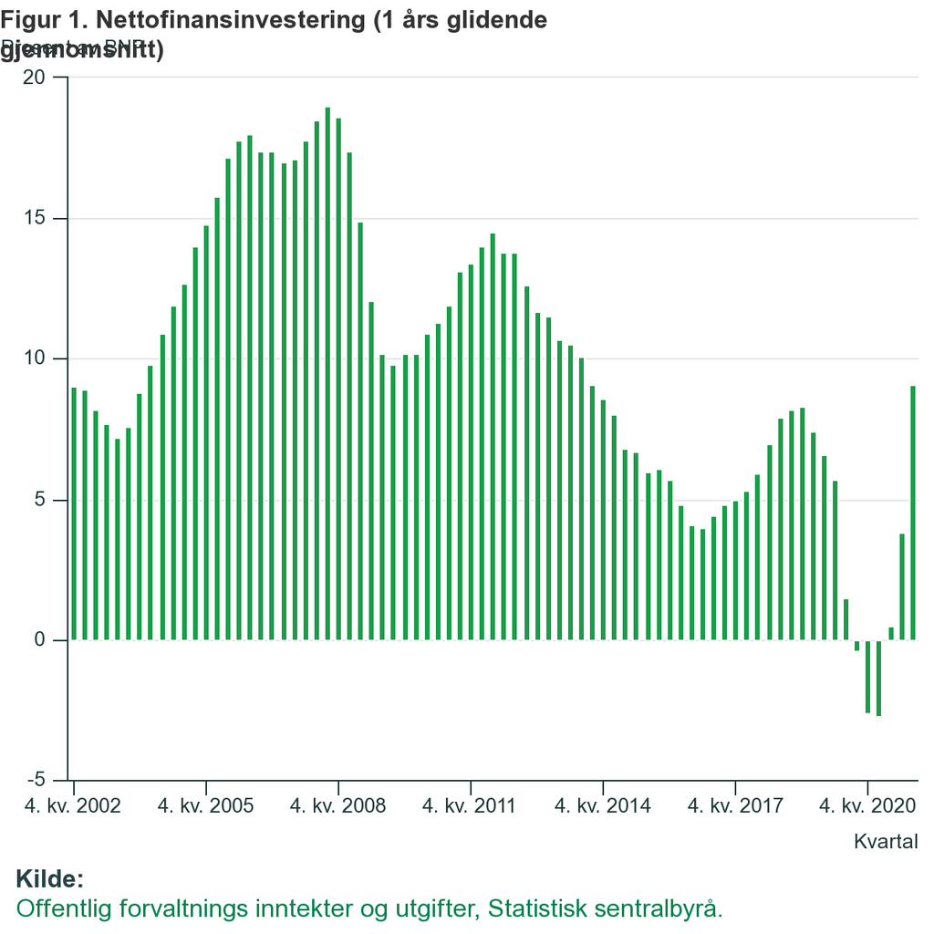

- presset på offentlige finanser øker
- aldringen av befolkningen gir økt behov for arbeidskraft i helse- og omsorgssektoren
- modellen må kontinuerlig vurderes, utvikles og styrkes

## Avhengig av økt sysselsetting

- den norske modellen er helt avhengig av **høy sysselsetting** for å kunne finansiere velferdsordningene framover
  - sysselsettingen faller etter fylte 62 år
    - jo flere eldre i arbeidsstyrken ==> reduserer sysselsettingsandelen
    - sysselsettingsandelene i disse aldersgruppene er økende
    - internasjonale trender (teknologisk utvikling og globalisering) vil føre til at jobber både forsvinner og blir skapt
      - nettoeffekten er usikker
        - de nye jobbene vil sannsynligvis kreve mer kompetanse enn jobbene som forsvinner
          - vanskeligere å inkludere sårbare grupper
  - nedbygging av petroleumssektoren vil også innebære omstillingsbehov
    - endringer i etterspørselen etter ulike typer arbeidskraft
    - kan svekke sysselsettingen, særlig i omstillingsfasen

## Behovet for arbeidskraft framover

### Økt press på offentlige finanser i årene fremover

- veksten i underliggende skatteinntekter avtar som følge av lavere befolkningsvekst og aldring

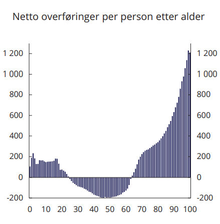

- innfasingen av oljepengebruk vil være betydelig lavere framover
  - inntektene fra olje- og gassvirksomheten vil avta
- aldringen av befolkningen øker utgiftene til alderspensjon og helse- og omsorgstjenester
- På lengre sikt
  - lavere inntekter og høyere utgifter fører til et **inndekningsbehov i offentlige finanser**
- fire ulike strategier for å dekke inndekningsbehovet (Perspektivmeldingen 2017)
  - økt sysselsetting
    - det mest attraktive alternativet
      - økt verdiskaping
      - økte inntekter
      - reduserte utgifter
      - gunstig for individer som kommer i arbeid
  - mer effektiv ressursbruk i offentlig sektor
    - Avbyråkratiserings- og effektiviseringsreformen (ABE-reformen): kutt i budsjettene i offentlig sektor tilsvarende anslått produktivitetsvekst
      - budsjettinnstramminger utover produktivitetsvekst vil svekke kvaliteten på tjenestene
    - lite sannsynlig at mer effektiv ressursbruk i offentlig sektor alene skal kunne dekke det framtidige inndekningsbehovet
  - økt privat ansvar
    - økt privat medfinansiering av offentlige tjenester
    - ansvaret for tjenester overføres til privat sektor
    - økte brukerbetalinger har uheldige fordelingsmessige konsekvenser
    - politisk krevende å gjennomføre
  - økte skatter
    - betydelig økning i skattenivået
      - negative effekter på arbeidstilbudet og på bedriftenes insentiver til å investere og drive næringsvirksomhet
      - bekjempelse av skatteunndragelse og et mer effektivt skattesystem kan bidra til å bedre ressursutnyttelsen

### Økt behov for arbeidskraft i helse- og omsorgssektoren

- Aldringen av befolkningen ==> ressursbruken i helse- og omsorgssektoren øker ==> økt behov for arbeidskraft
- For å møte behovet for arbeidskraft vil det måtte være 15 prosent av sysselsatte i helse- og omsorgssektoren i 2035, og 22 prosent i 2060 (Hjemås m.fl. 2019)
  - vil være en fjerdedel av den totale sysselsettingsveksten fram til 2035, og halvparten mellom 2035 og 2060
- faktorer som bremser etterspørselsveksten
  - bedre helse blant eldre
  - økt bruk av velferdsteknologi øker produktiviteten
- faktorer som øker etterspørselsveksten etter arbeidskraft i sektoren
  - økt standard på helsetjenestene
  - økt velstandsnivå gir forventning om stadig bedre tjenester
  - nye og kostbare behandlingsmuligheter blir tilgjengelig
- etterspørselen etter arbeidskraft vil trolig også øke i andre sektorer (Cappelen m.fl. 2020)
  - etterspørselen vil vokse klart sterkere enn arbeidsstyrken for personer med videregående fagutdanning rettet inn mot industri, bygg og anlegg og håndverk

## Sysselsetting og megatrender

## Automatisering og teknologisk utvikling

- Teknologisk utvikling har både positive og negative effekter på sysselsettingen
  - **teknologi erstatter mennesker** i utførelsen av oppgaver
    - **negativ effekt på sysselsettingen**
    - økt produktivitet ==> prisreduksjoner ==> økt etterspørsel
  - **ny teknologi komplementerer menneskelig arbeidskraft** ==> øker produktiviteten til arbeidstakere
    - innovasjon ==> nye produkter og teknologi ==> økt produktivitet ==> lønningene opp og prisene ned ==> økt kjøpekraft, økte investeringer og økt etterspørsel etter arbeidskraft ==> nye arbeidsplasser
    - **positive sysselsettingseffekter**
  - ny teknologi kan også skape helt nye jobber
- Totaleffekten avhenger hvilken effekt som er sterkest
  - “Ny teknologi og arbeidskraft er komplementer”:
    - Atkinson og Wu(2017), Marcussen (2016):
      - frykten for teknologidrevet ledighet er sterkt overdrevet
      - takten i yrkesmobilitet og jobbtap under de seinere års tekniske rasjonalisering har vært lav de senere årene
  - “Ny teknologi og arbeid er substitutter”:
    - maskinlæring, automatisering, roboter og andre digitale verktøy gjør arbeidskraft overflødig
      - spesielt innenfor rutinepregede aktiviteter
      - også jobber som hovedsakelig består av kognitive oppgaver og var ansett som umulige å automatisere, er nå i faresonen (Brynjolfsson & McAfee 2014)
- utfordringene automatiseringen skaper må vurderes i forhold til de store endringene som uansett skjer hvert år i arbeidsmarkedet
  - hvert år forsvinner om lag hver tiende jobb, mens enda flere jobber kommer til
- økt polarisering på arbeidsmarkedet: ny teknologi har konsekvenser for hvilke typer jobber som finnes
  - etterspørselen etter ulike typer arbeidstakere vil ikke være konstant
    - etterspørselen etter arbeidstakere som utfører kognitivt krevende oppgaver øker som følge av informasjonsteknologi
    - noen jobber som krever middels kompetanse står i fare for å bli automatisert bort
    - mange jobber i tjenestesektoren er vanskelig å automatisere

## Globalisering (eller antiglobalisering?)

- Små, åpne vestlige økonomier har høstet store gevinster av liberaliseringen av internasjonal handel i etterkrigstiden
  - globalisering av finanssektoren har derimot hatt mer tvetydige virkninger
- Selv om de nordiske økonomiene har vært blant globaliseringsvinnerne, har arbeidsplasser i flere bransjer og næringer gått tapt
  - omstrukturering av internasjonale produksjons- og verdikjeder har ført til relokalisering av manuelle jobber
    - parallelt med vekst i kunnskapsintensive jobber på hjemmebane
- fri bevegelse av tjenester og arbeidskraft får økende betydning for vekst- og omstillingsevnen i arbeidslivet
  - norsk eksport til EU dominert av olje, gass, ubearbeidet fisk og råvarebaserte industriprodukter
    - Hvis målet i framtiden er å utvikle mer kunnskapsbasert digital, grønn eksportproduksjon med større innslag av tjenester, vil det økonomisk sett neppe være noen fordel om Norge stiller seg utenfor EU
- lavere kommunikasjons- og transportkostnader har knyttet sammen markeder for varer og tjenester
- har bidratt til akselererende spredning av teknologi og data, informasjon og kunnskapsbaserte tjenester
- flere tjenester kan bli formidlet online uten hensyn til geografisk avstand
  - økt innovasjonstakt og forsterket internasjonal konkurranse
  - et mulig scenario: globalisering innen kunnskapsintensiv produksjon og online-tjenester, utflyttingen av tradisjonell arbeidsintensiv produksjon bremses opp

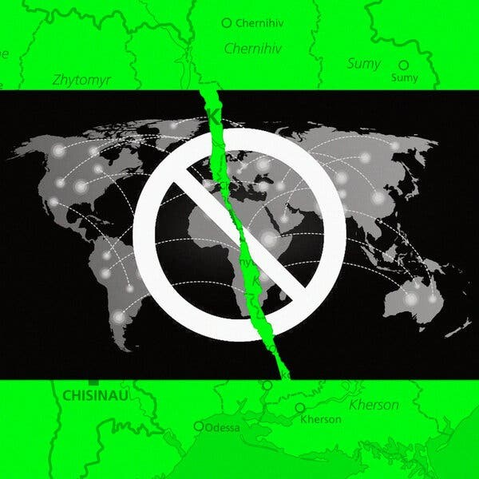